# Capstone: Milestone Report

Amit Kohli

March 18, 2016

# Summary

The goal of this report is to download data (https://d396qusza40orc.cloudfront.net/dsscapstone/dataset/Coursera-SwiftKey.zip) and conduct initial exploratory analysis and demonstrate goals for the eventual application and algorithm. This document explains the major features of the data identified and briefly summarizes plans for creating the prediction algorithm and Shiny app in a way that would be understandable to a non-data scientist manager. The objective for this report are: 1. Demonstrate that the data has been successfully downloaded and loaded 2. Create a basic report of summary statistics about the data sets. 3. Report any interesting findings 4. Receive feedback on plans for creating a prediction algorithm and Shiny app.

# Libraries

Libraries used in this study.

```r
library(stringi)
library(tm)
library(RWeka)
```

```r
library(ggplot2)
library(dplyr)
```

# Downloading and loading the data

The data has been downloaded from this link: https://d396qusza40orc.cloudfront.net/dsscapstone/dataset/Coursera-SwiftKey.zip, uncompressed, and stored in the “Data” folder within the Working Directory.

There are four languages in this data set. On on each directory.

```r
list.files("data/final")
```

```
## [1] "de_DE" "en_US" "fi_FI" "ru_RU"
```

The report conducts analysis on the English data, there are 3 files from different sources in data:

```r
list.files("data/final/en_US")
```

```
## [1] "en_US.blogs.txt"   "en_US.news.txt"    "en_US.twitter.txt"
```

The source of the files are from:

- News
- Blogs
- Twitter

# Exploratory Analisys

Load the three files to obtain some basic information about then.

```r
blog.file <- "data/final/en_US/en_US.blogs.txt"
twitter.file <- "data/final/en_US/en_US.twitter.txt"
news.file <- "data/final/en_US/en_US.news.txt"
blogs <- readLines(blog.file, encoding="UTF-8")
twitter <- readLines(twitter.file, encoding="UTF-8")
news  <- readLines(news.file, encoding="UTF-8")
```

**Blog file:** * File name: data/final/en_US/en_US.blogs.txt. * File size: 200.42 MB. * Lines and chars statistics on the file:

```r
data.frame(t(stri_stats_general(blogs)))
```

```
##    Lines LinesNEmpty     Chars CharsNWhite
## 1 899288      899288 206824382   170389539
```

- Summary of the char quantities per line:

```r
summary(sapply(blogs,FUN=nchar))
```

```
##    Min. 1st Qu.  Median    Mean 3rd Qu.    Max.
##       1      47     156     230     329   40830
```

- Words count summary:

```r
summary(stri_count_words(blogs))
```

```
##    Min. 1st Qu.  Median    Mean 3rd Qu.    Max.
##    0.00    9.00   28.00   41.75   60.00 6726.00
```

**Twitter file:** * File name: data/final/en_US/en_US.twitter.txt. * File size: 159.36 MB. * Lines and chars statistics on the file:

```r
data.frame(t(stri_stats_general(twitter)))
```

```
##     Lines LinesNEmpty     Chars CharsNWhite
## 1 2360148     2360148 162096031   134082634
```

- Summary of the char quantities per line:

```r
summary(sapply(twitter,FUN=nchar))
```

```
##    Min. 1st Qu.  Median    Mean 3rd Qu.    Max.
##    2.00   37.00   64.00   68.68  100.00  140.00
```

- Words count summary:

```r
summary(stri_count_words(twitter))
```

```
##    Min. 1st Qu.  Median    Mean 3rd Qu.    Max.
##    1.00    7.00   12.00   12.75   18.00   47.00
```

**News feed:** * File name: data/final/en_US/en_US.news.txt. * File size: 196.28 MB. * Lines and chars statistics on the file:

```r
data.frame(t(stri_stats_general(news)))
```

```
##     Lines LinesNEmpty     Chars CharsNWhite
## 1 1010242     1010242 203223154   169860866
```

- Summary of the char quantities per line:

```r
summary(sapply(news,FUN=nchar))
```

```
##    Min. 1st Qu.  Median    Mean 3rd Qu.    Max.
##     1.0   110.0   185.0   201.2   268.0 11380.0
```

- Words count summary:

```r
summary(stri_count_words(news))
```

```
##    Min. 1st Qu.  Median    Mean 3rd Qu.    Max.
##    1.00   19.00   32.00   34.41   46.00 1796.00
```

## Data Cleanning and Preprocessing

Due to large file size, the report will extract smaller samples to work with.

```r
sample.size <- 100000
sample.blogs <- sample(blogs,sample.size)
sample.twitter <- sample(twitter,sample.size)
sample.news <- sample(news,sample.size)
```

- Sample Blogs has 11.12% of the original data.
- Sample Twitter has 4.24% of the original data.
- Sample News has 9.9% of the original data.

For reproducible research, the report will save the samples and load them as needed.

```r
save(sample.blogs,sample.twitter,sample.news,file="samples.RData")
```

```r
load("samples.RData")
```

First, convert the encoding of the characters, removing the non-convertible characters.

```r
sample.blogs <- iconv(sample.blogs, "latin1", "ASCII", sub="")
sample.twitter <- iconv(sample.twitter, "latin1", "ASCII", sub="")
sample.news <- iconv(sample.news, "latin1", "ASCII", sub="")
```

Next, clean the data by converting to lower case, removing punctuation, numbers, and profanities. The list of profanity words was obtained from https://github.com/shutterstock/List-of-Dirty-Naughty-Obscene-and-Otherwise-Bad-Words/blob/master/en).

```r
profanity.words <- readLines("profanity.txt")
corpus.blogs <- Corpus(VectorSource(list(sample.blogs)))
corpus.blogs <- tm_map(corpus.blogs, content_transformer(tolower))
corpus.blogs <- tm_map(corpus.blogs, content_transformer(removePunctuation))
corpus.blogs <- tm_map(corpus.blogs, content_transformer(removeNumbers))
corpus.blogs <- tm_map(corpus.blogs, removeWords, stopwords("english"))
corpus.blogs <- tm_map(corpus.blogs, removeWords, profanity.words)
corpus.blogs <- tm_map(corpus.blogs, stripWhitespace)
corpus.blogs <- tm_map(corpus.blogs, stemDocument, language='english')
```

```r
corpus.twitter <- Corpus(VectorSource(list(sample.twitter)))
corpus.twitter <- tm_map(corpus.twitter, content_transformer(tolower))
corpus.twitter <- tm_map(corpus.twitter, content_transformer(removePunctuation))
corpus.twitter <- tm_map(corpus.twitter, content_transformer(removeNumbers))
corpus.twitter <- tm_map(corpus.twitter, removeWords, stopwords("english"))
corpus.twitter <- tm_map(corpus.twitter, removeWords, profanity.words)
corpus.twitter <- tm_map(corpus.twitter, stripWhitespace)
corpus.twitter <- tm_map(corpus.twitter, stemDocument, language='english')
```

```r
corpus.news <- Corpus(VectorSource(list(sample.news)))
corpus.news <- tm_map(corpus.news, content_transformer(tolower))
corpus.news <- tm_map(corpus.news, content_transformer(removePunctuation))
corpus.news <- tm_map(corpus.news, content_transformer(removeNumbers))
corpus.news <- tm_map(corpus.news, removeWords, stopwords("english"))
corpus.news <- tm_map(corpus.news, removeWords, profanity.words)
corpus.news <- tm_map(corpus.news, stripWhitespace)
corpus.news <- tm_map(corpus.news, stemDocument, language='english')
```

## Data Analysis

N-Grams analysis approach is used on the data [N-Grams](http://en.wikipedia.org/wiki/N-gram).

### Unigram analysis

The report generates the unigrams and plot the top ten frequency of each sample.

#### Blogs

Top ten words:

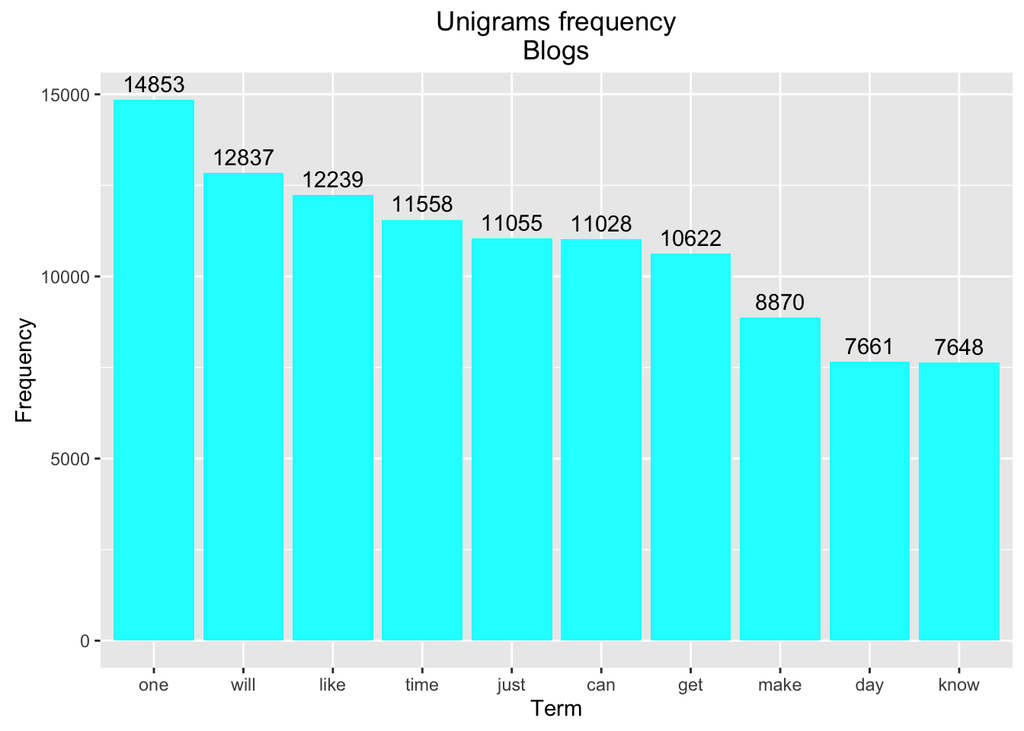

```r
UnigramTokenizer <- function(x) NGramTokenizer(x, Weka_control(min = 1, max = 1))
unigram.termdocmatrix.blogs <- TermDocumentMatrix(corpus.blogs, control = list(tokenize = UnigramTokenizer))
unigram.df.blogs <- data.frame(Term = unigram.termdocmatrix.blogs$dimnames$Terms,
                                 Freq = unigram.termdocmatrix.blogs$v)
unigram.df.blogs <- unigram.df.blogs[order(unigram.df.blogs$Freq,decreasing = T),]

ggplot(head(unigram.df.blogs,10), aes(x=reorder(Term,-Freq), y=Freq)) +
  geom_bar(stat="Identity", fill="cyan") +
  geom_text(aes(label=Freq), vjust = -0.5) +
  ggtitle("Unigrams frequency\nBlogs") +
  ylab("Frequency") +
  xlab("Term")
```

- 80508 unique words on this sample.
- 45720 words occurs only one time.

How many words we need to cover 50% of the instances?

```r
cumsum.blogs <- cumsum(unigram.df.blogs$Freq)
limit.50.blogs <- sum(unigram.df.blogs$Freq)*0.5
length((cumsum.blogs[cumsum.blogs <=  limit.50.blogs]))
```

```
## [1] 545
```

How many word to cover 90% of the instances?

```r
limit.90.blogs <- sum(unigram.df.blogs$Freq)*0.9

length((cumsum.blogs[cumsum.blogs <=  limit.90.blogs]))
```

```
## [1] 6721
```

#### Twitter

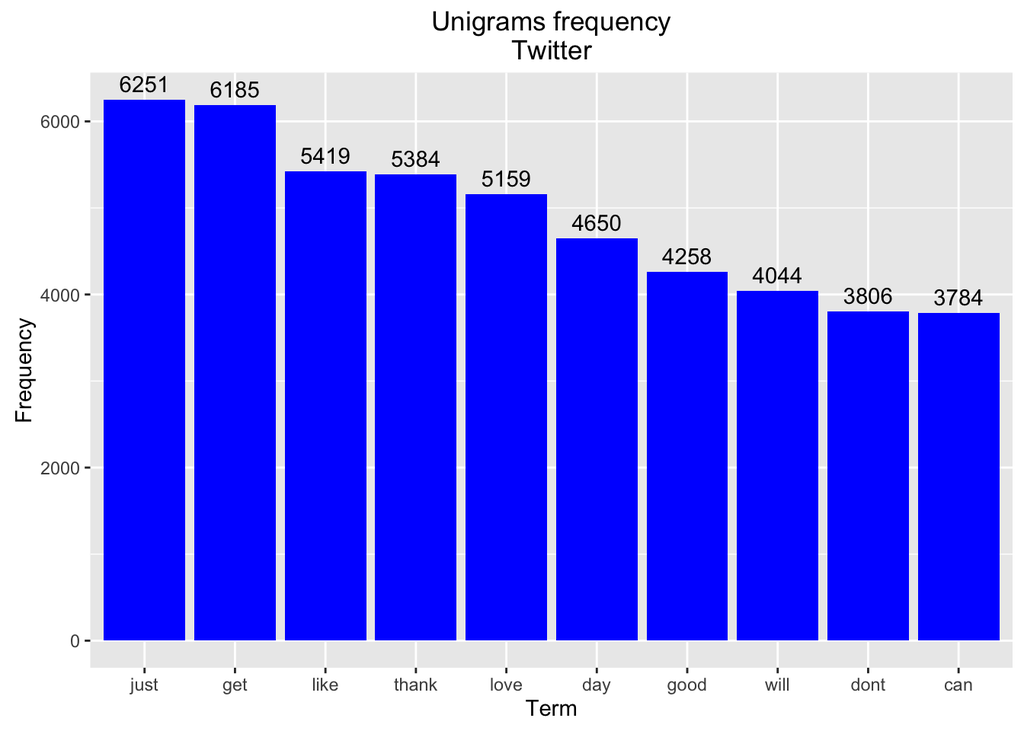

```r
unigram.termdocmatrix.twitter <- TermDocumentMatrix(corpus.twitter, control = list(tokenize = UnigramTokenizer))
unigram.df.twitter <- data.frame(Term = unigram.termdocmatrix.twitter$dimnames$Terms,
                                 Freq = unigram.termdocmatrix.twitter$v)
unigram.df.twitter <- unigram.df.twitter[order(unigram.df.twitter$Freq,decreasing = T),]

ggplot(head(unigram.df.twitter,10), aes(x=reorder(Term,-Freq), y=Freq)) +
  geom_bar(stat="Identity", fill="blue") +
  geom_text(aes(label=Freq), vjust = -0.5) +
  ggtitle("Unigrams frequency\nTwitter") +
  ylab("Frequency") +
  xlab("Term")
```

- 48821 unique words on this sample.
- 31105 words occurs only one time.

How many words we need to cover 50% of the instances?

```r
cumsum.twitter <- cumsum(unigram.df.twitter$Freq)
limit.50.twitter <- sum(unigram.df.twitter$Freq)*0.5
length((cumsum.twitter[cumsum.twitter <=  limit.50.twitter]))
```

```
## [1] 347
```

How many word to cover 90% of the instances?

```r
limit.90.twitter <- sum(unigram.df.twitter$Freq)*0.9
length((cumsum.twitter[cumsum.twitter <=  limit.90.twitter]))
```

```
## [1] 6303
```

#### News

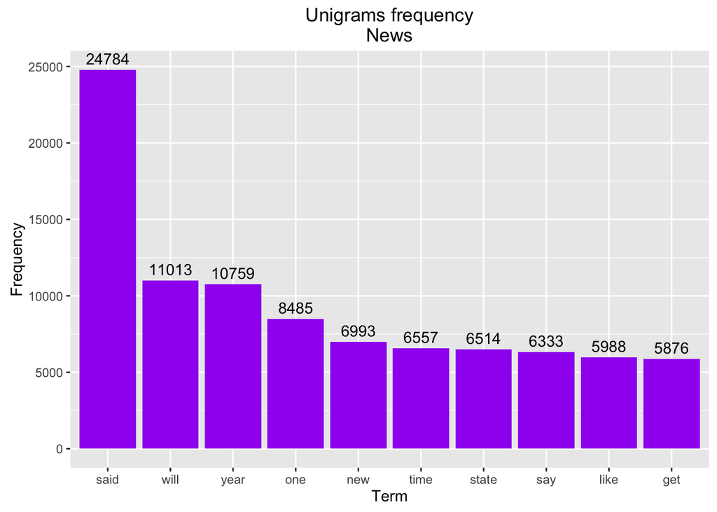

```r
unigram.termdocmatrix.news <- TermDocumentMatrix(corpus.news, control = list(tokenize = UnigramTokenizer))
unigram.df.news <- data.frame(Term = unigram.termdocmatrix.news$dimnames$Terms,
                                 Freq = unigram.termdocmatrix.news$v)
unigram.df.news <- unigram.df.news[order(unigram.df.news$Freq,decreasing = T),]

ggplot(head(unigram.df.news,10), aes(x=reorder(Term,-Freq), y=Freq)) +
  geom_bar(stat="Identity", fill="purple") +
  geom_text(aes(label=Freq), vjust = -0.5) +
  ggtitle("Unigrams frequency\nNews") +
  ylab("Frequency") +
  xlab("Term")
```

- 72315 unique words on this sample.
- 36172 words occurs only one time.

How many words we need to cover 50% of the instances?

```r
cumsum.news <- cumsum(unigram.df.news$Freq)
limit.50.news <- sum(unigram.df.news$Freq)*0.5
length((cumsum.news[cumsum.news <=  limit.50.news]))
```

```
## [1] 660
```

How many word to cover 90% of the instances?

```r
limit.90.news <- sum(unigram.df.news$Freq)*0.9
length((cumsum.news[cumsum.news <=  limit.90.news]))
```

```
## [1] 7462
```

### Bigram analysis

The report conducts bigrams analysis for the samples.

#### Blogs

Top ten words:

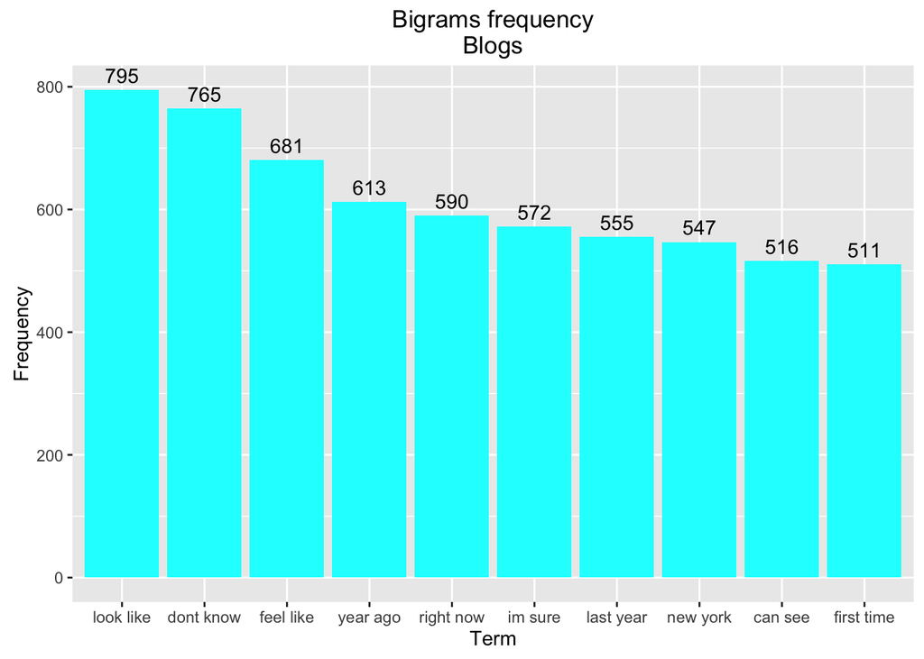

```r
BigramTokenizer <- function(x) NGramTokenizer(x, Weka_control(min = 2, max = 2))
bigram.termdocmatrix.blogs <- TermDocumentMatrix(corpus.blogs, control = list(tokenize = BigramTokenizer))

bigram.df.blogs <- data.frame(Term = bigram.termdocmatrix.blogs$dimnames$Terms,
                                 Freq = bigram.termdocmatrix.blogs$v)
bigram.df.blogs <- bigram.df.blogs[order(bigram.df.blogs$Freq,decreasing = T),]

ggplot(head(bigram.df.blogs,10), aes(x=reorder(Term,-Freq), y=Freq)) +
  geom_bar(stat="Identity", fill="cyan") +
  geom_text(aes(label=Freq), vjust = -0.5) +
  ggtitle("Bigrams frequency\nBlogs") +
  ylab("Frequency") +
  xlab("Term")
```

- 1301573 unique bigrams on this sample.
- 1067172 bigrams occurs only one time.

How many bigrams we need to cover 50% of the instances?

```r
cumsum.blogs <- cumsum(bigram.df.blogs$Freq)
limit.50.blogs <- sum(bigram.df.blogs$Freq)*0.5
length((cumsum.blogs[cumsum.blogs <=  limit.50.blogs]))
```

```
## [1] 282341
```

How many bigrams to cover 90% of the instances?

```r
limit.90.blogs <- sum(bigram.df.blogs$Freq)*0.9
length((cumsum.blogs[cumsum.blogs <=  limit.90.blogs]))
```

```
## [1] 1097726
```

#### Twitter

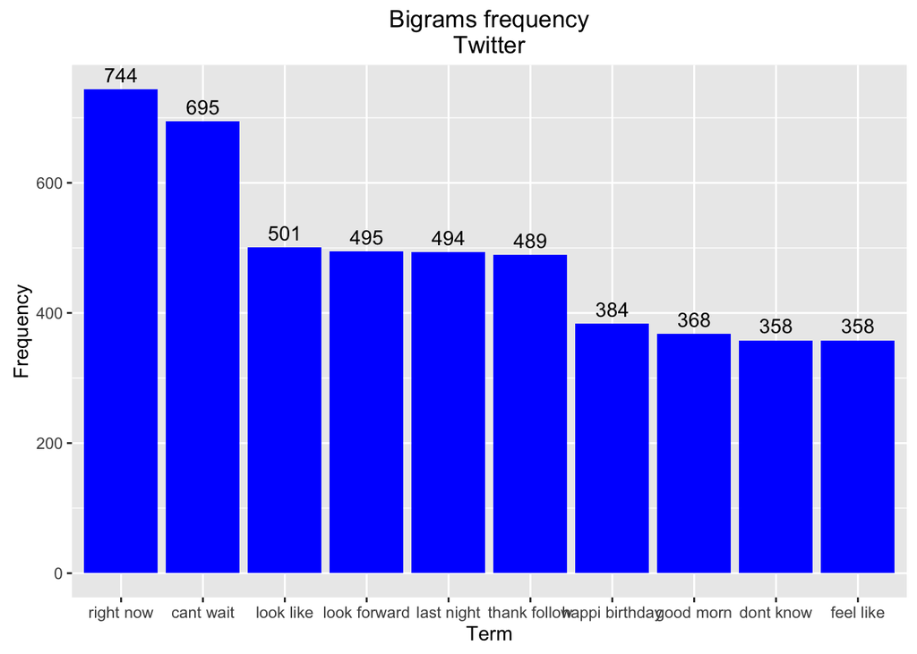

```r
bigram.termdocmatrix.twitter <- TermDocumentMatrix(corpus.twitter, control = list(tokenize = BigramTokenizer))

bigram.df.twitter <- data.frame(Term = bigram.termdocmatrix.twitter$dimnames$Terms,
                                 Freq = bigram.termdocmatrix.twitter$v)
bigram.df.twitter <- bigram.df.twitter[order(bigram.df.twitter$Freq,decreasing = T),]

ggplot(head(bigram.df.twitter,10), aes(x=reorder(Term,-Freq), y=Freq)) +
  geom_bar(stat="Identity", fill="blue") +
  geom_text(aes(label=Freq), vjust = -0.5) +
  ggtitle("Bigrams frequency\nTwitter") +
  ylab("Frequency") +
  xlab("Term")
```

- 425968 unique bigrams on this sample.
- 363014 bigrams occurs only one time.

How many bigrams we need to cover 50% of the instances?

```r
cumsum.twitter <- cumsum(bigram.df.twitter$Freq)
limit.50.twitter <- sum(bigram.df.twitter$Freq)*0.5
length((cumsum.twitter[cumsum.twitter <=  limit.50.twitter]))
```

```
## [1] 109416
```

How many bigrams to cover 90% of the instances?

```r
limit.90.twitter <- sum(bigram.df.twitter$Freq)*0.9
length((cumsum.twitter[cumsum.twitter <=  limit.90.twitter]))
```

```
## [1] 362657
```

#### News

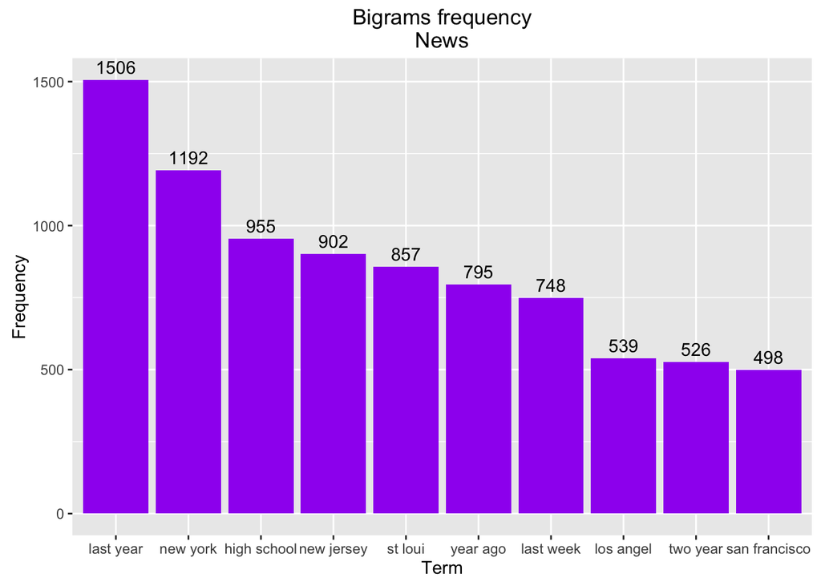

```r
bigram.termdocmatrix.news <- TermDocumentMatrix(corpus.news, control = list(tokenize = BigramTokenizer))

bigram.df.news <- data.frame(Term = bigram.termdocmatrix.news$dimnames$Terms,
                                 Freq = bigram.termdocmatrix.news$v)
bigram.df.news <- bigram.df.news[order(bigram.df.news$Freq,decreasing = T),]

ggplot(head(bigram.df.news,10), aes(x=reorder(Term,-Freq), y=Freq)) +
  geom_bar(stat="Identity", fill="purple") +
  geom_text(aes(label=Freq), vjust = -0.5) +
  ggtitle("Bigrams frequency\nNews") +
  ylab("Frequency") +
  xlab("Term")
```

How many bigrams we need to cover 50% of the instances?

```r
cumsum.news <- cumsum(bigram.df.news$Freq)
limit.50.news <- sum(bigram.df.news$Freq)*0.5
length((cumsum.news[cumsum.news <=  limit.50.news]))
```

```
## [1] 269510
```

How many bigrams to cover 90% of the instances?

```r
limit.90.news <- sum(bigram.df.news$Freq)*0.9
length((cumsum.news[cumsum.news <=  limit.90.news]))
```

```
## [1] 1006758
```

# Next Steps

1. Build a prediction model: Research how to evaluate the model; Test Markov chain and Naive Bayes; Test other algorithms that can predict probability for more than one response; Use 2-gram, 3-gram, 4-gram and 5-gram to predict the next word; Use Katz’s back-off model; and Research how to predict a response when a word/N-gram is never reflected in the data.
2. Create shinny app: Consider the size in memory and performance (runtime) of the model; Develop the app; Publish the app in shinyapps.io and check the resources consumption; Conduct regression and user testing.
3. Create Final Report!